# What are the determinants of life expectancy?

# by Eugenia Fernandez

## Abstract

What factors account for the differences in life expectancy among countries? Do countries in tropical regions and with higher prevalence of infectious diseases have lower life expectancy? Or, is it merely a countries income level(GPA)? Sanitation level? What are the effects of CO2 emissions? Are all these differences equal across genders too?

This project will explore these questions using data from the the World Bank’s World Development Indicators(WDI).

# Univariate Plots Section

### Brief summary of the dataset

Let’s first see what variables are in the dataset and do some summary statistics of all indicators.

```
## 'data.frame':    1787 obs. of  25 variables:
##  $ iso2c           : chr  "AE" "AE" "AE" "AE" ...
##  $ country         : chr  "United Arab Emirates" "United Arab Emirates" "United Arab Emirates" "United Arab Emirates" ...
##  $ year            : num  2005 2006 2013 2012 2008 ...
##  $ life.expect.f   : num  76.8 77 78.3 78.2 77.4 ...
##  $ life.expect     : num  75.7 75.9 77.2 77 76.3 ...
##  $ life.expect.m   : num  74.6 74.8 76.1 76 75.2 ...
##  $ gdp.pc          : num  40299 38363 26402 25555 30613 ...
##  $ health.expend.pc: num  1010 1060 1569 1235 1238 ...
##  $ co2.em.pc       : num  25.9 24 NA NA 23 ...
##  $ urban.pop.pct   : num  82.3 82.6 85 84.7 83.4 ...
##  $ rural.pop.pct   : num  17.7 17.4 15 15.3 16.6 ...
##  $ unemp.rate.f    : num  7 7.7 8.9 9.1 12.9 ...
##  $ unemp.rate.m    : num  2.5 2.5 2.9 3 2.4 ...
##  $ unemp.rate.tot  : num  3.1 3.3 3.8 4 4 ...
##  $ population      : num  4481976 5171255 9039978 8952542 6900142 ...
##  $ san.access.pct  : num  97.5 97.5 97.5 97.5 97.5 97.5 97.5 97.5 97.5 26.9 ...
##  $ iso3c           : Factor w/ 248 levels "ABW","AFG","AGO",..: 7 7 7 7 7 7 7 7 7 2 ...
##  $ region          : Factor w/ 8 levels "Aggregates","East Asia & Pacific (all income levels)",..: 5 5 5 5 5 5 5 5 5 7 ...
##  $ capital         : Factor w/ 211 levels "","Abu Dhabi",..: 2 2 2 2 2 2 2 2 2 80 ...
##  $ longitude       : Factor w/ 211 levels "","-0.126236",..: 186 186 186 186 186 186 186 186 186 194 ...
##  $ latitude        : num  24.5 24.5 24.5 24.5 24.5 ...
##  $ income          : Factor w/ 7 levels "Aggregates","High income: nonOECD",..: 2 2 2 2 2 2 2 2 2 4 ...
##  $ lending         : Factor w/ 5 levels "Aggregates","Blend",..: 5 5 5 5 5 5 5 5 5 4 ...
##  $ tropic          : Factor w/ 2 levels "FALSE","TRUE": 1 1 1 1 1 1 1 1 1 1 ...
##  $ rural           : Factor w/ 2 levels "FALSE","TRUE": 1 1 1 1 1 1 1 1 1 2 ...
```

Since the focus of this study is on the determinants of life expectancy, let’s first focus on this indicator.

#### Average total life expectancy

```
##    Min. 1st Qu.  Median    Mean 3rd Qu.    Max.
##   41.76   64.11   72.57   69.90   76.62   83.83
```

#### Average female life expectancy

```
##    Min. 1st Qu.  Median    Mean 3rd Qu.    Max.
##   41.29   65.83   75.50   72.35   79.85   86.70
```

#### Average male life expectancy

```
##    Min. 1st Qu.  Median    Mean 3rd Qu.    Max.
##   42.20   61.79   69.48   67.57   74.22   81.80
```

#### Histogram of average life expectancy

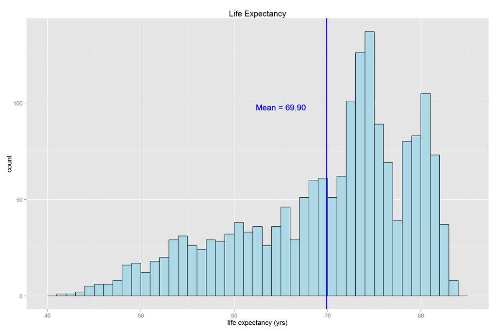

The distribution looks skewed to the left, indicating that the majority of countries concentrate on longer life expectancy values but there are a few countries with very low values of life expectancy. There is also a large percentage of individuals concentrated around 74 and around 80.

#### Histogram of female average life expectancy

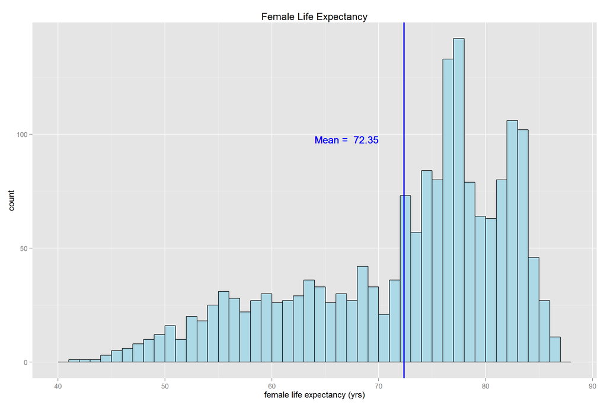

This is similar when looking only at women.

#### Histogram of male average life expectancy

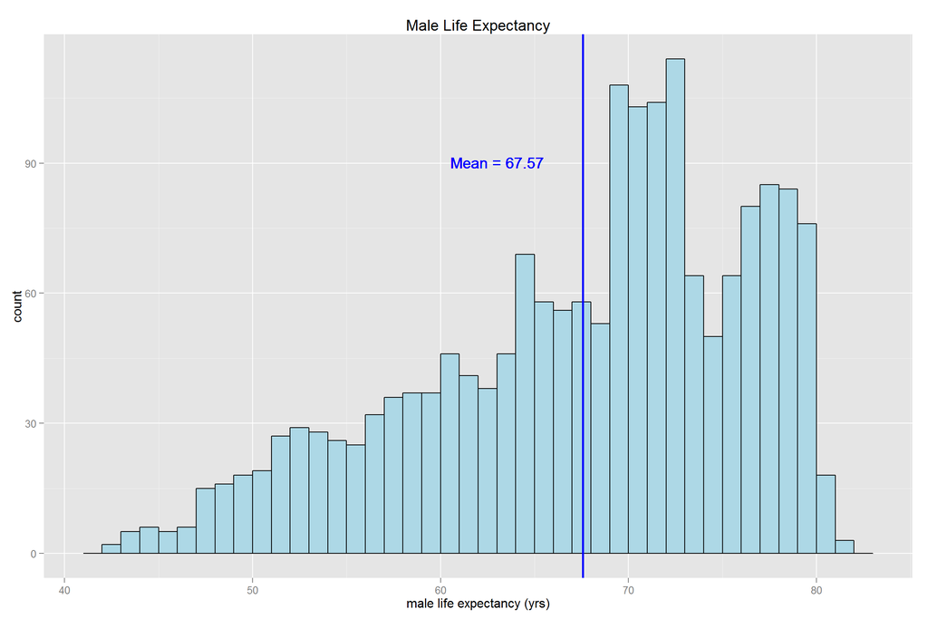

Men’s distribution is less skewed and average life expectancy is greater for women than for men.

### life expectancy by year

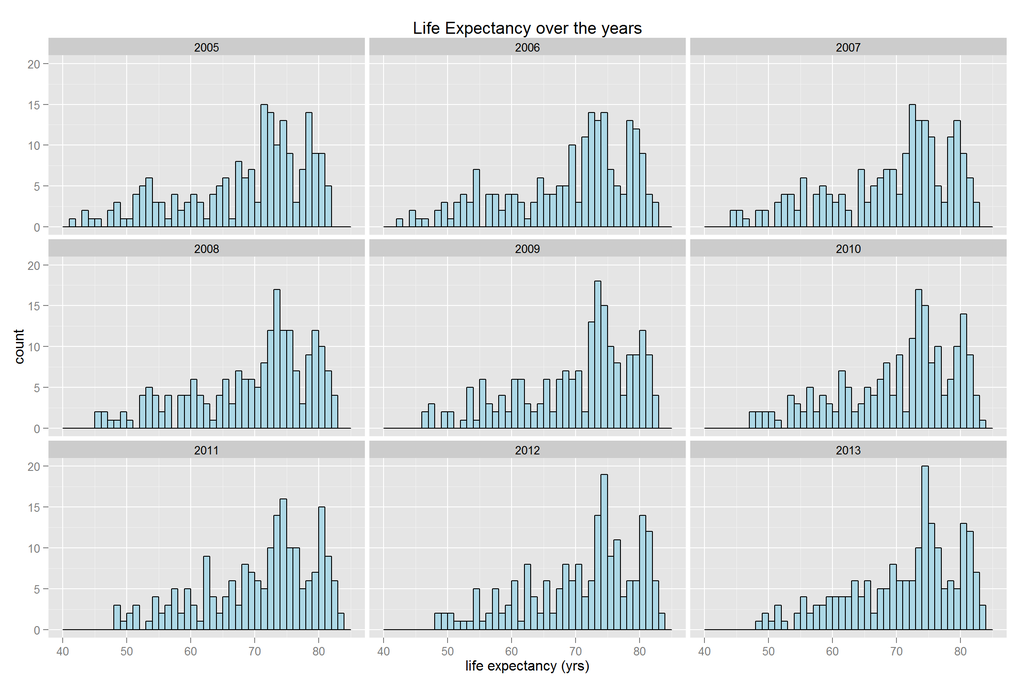

The left skewed distribution continues in these graphs when we facet the data by year.

### Change in life expectancy by year

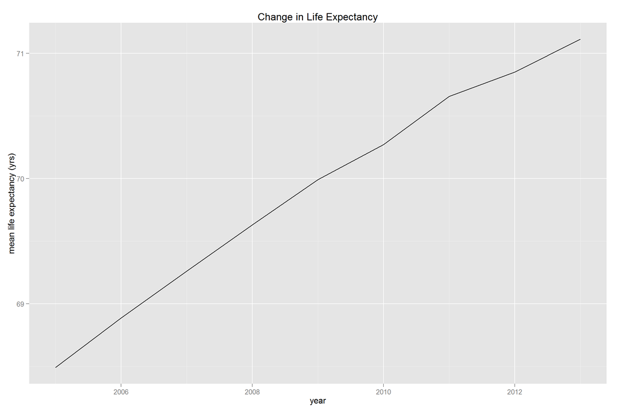

### Rate of change in life expectancy

```
## [1] 0.3277756
```

Mean life expectancy increased over time, at an average rate of approximately less than .35 years per year.

### Distributional differences in life expectancy among countries across years.

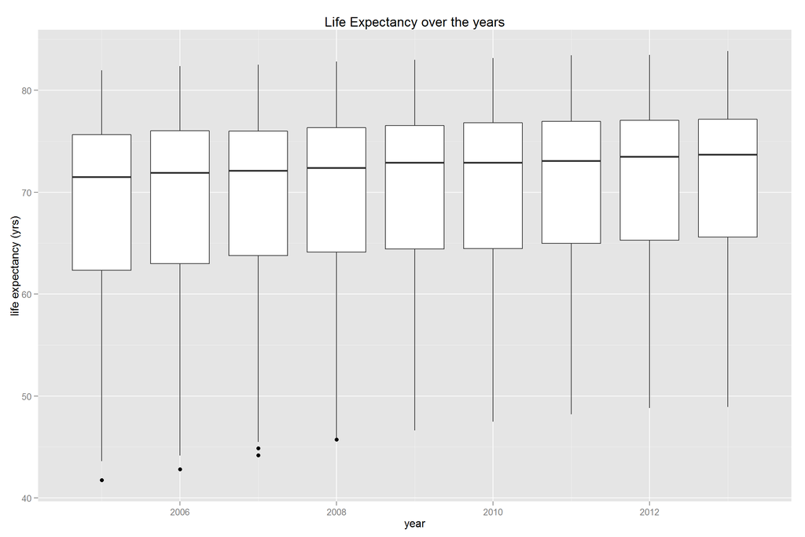

Looking at boxplots, we see that there were negative outliers in 2005 to 2008 and that observations appear to have less dispersion in 2013. From looking at this graph, there seems to be a trend of convergence.

### Other indicators

```
##     iso2c             country               year      life.expect.f
##  Length:1787        Length:1787        Min.   :2005   Min.   :41.29
##  Class :character   Class :character   1st Qu.:2007   1st Qu.:65.83
##  Mode  :character   Mode  :character   Median :2009   Median :75.50
##                                        Mean   :2009   Mean   :72.35
##                                        3rd Qu.:2011   3rd Qu.:79.85
##                                        Max.   :2013   Max.   :86.70
##
##   life.expect    life.expect.m       gdp.pc         health.expend.pc
##  Min.   :41.76   Min.   :42.20   Min.   :   140.8   Min.   :   4.722
##  1st Qu.:64.11   1st Qu.:61.79   1st Qu.:   929.7   1st Qu.:  64.201
##  Median :72.57   Median :69.48   Median :  3672.1   Median : 255.323
##  Mean   :69.90   Mean   :67.57   Mean   : 11384.0   Mean   : 939.533
##  3rd Qu.:76.62   3rd Qu.:74.22   3rd Qu.: 14160.1   3rd Qu.: 814.110
##  Max.   :83.83   Max.   :81.80   Max.   :117067.3   Max.   :9714.786
##                                  NA's   :132        NA's   :171
##    co2.em.pc       urban.pop.pct     rural.pop.pct    unemp.rate.f
##  Min.   : 0.0194   Min.   :  8.666   Min.   : 0.00   Min.   : 0.1
##  1st Qu.: 0.6030   1st Qu.: 36.026   1st Qu.:24.54   1st Qu.: 4.8
##  Median : 2.4307   Median : 55.559   Median :44.44   Median : 7.7
##  Mean   : 4.8934   Mean   : 55.914   Mean   :44.09   Mean   :10.1
##  3rd Qu.: 6.8205   3rd Qu.: 75.456   3rd Qu.:63.97   3rd Qu.:12.5
##  Max.   :61.9898   Max.   :100.000   Max.   :91.33   Max.   :44.8
##  NA's   :452       NA's   :9         NA's   :9       NA's   :230
##   unemp.rate.m    unemp.rate.tot     population        san.access.pct
##  Min.   : 0.100   Min.   : 0.100   Min.   :1.991e+04   Min.   :  6.60
##  1st Qu.: 4.100   1st Qu.: 4.400   1st Qu.:1.481e+06   1st Qu.: 45.20
##  Median : 6.500   Median : 7.000   Median :6.930e+06   Median : 85.60
##  Mean   : 7.771   Mean   : 8.519   Mean   :3.433e+07   Mean   : 71.16
##  3rd Qu.: 8.900   3rd Qu.:10.600   3rd Qu.:2.235e+07   3rd Qu.: 97.10
##  Max.   :36.500   Max.   :37.600   Max.   :1.357e+09   Max.   :100.00
##  NA's   :230      NA's   :230                          NA's   :120
##      iso3c                                                 region
##  ABW    :   9   Europe & Central Asia (all income levels)     :473
##  AFG    :   9   Sub-Saharan Africa (all income levels)        :423
##  AGO    :   9   Latin America & Caribbean (all income levels) :323
##  ALB    :   9   East Asia & Pacific (all income levels)       :280
##  ARE    :   9   Middle East & North Africa (all income levels):189
##  ARG    :   9   South Asia                                    : 72
##  (Other):1733   (Other)                                       : 27
##         capital         longitude       latitude
##             :  45            :  35   Min.   :-41.286
##  Abu Dhabi  :   9   -0.126236:   9   1st Qu.:  3.872
##  Abuja      :   9   -0.20795 :   9   Median : 17.993
##  Accra      :   9   -1.53395 :   9   Mean   : 18.835
##  Addis ababa:   9   -10.7957 :   9   3rd Qu.: 39.715
##  Agana      :   9   -13.2134 :   9   Max.   : 64.184
##  (Other)    :1697   (Other)  :1707   NA's   :35
##                   income              lending      tropic      rural
##  Aggregates          :  0   Aggregates    :  0   FALSE:860   FALSE:1030
##  High income: nonOECD:274   Blend         :126   TRUE :892   TRUE : 748
##  High income: OECD   :279   IBRD          :541   NA's : 35   NA's :   9
##  Low income          :315   IDA           :558
##  Lower middle income :468   Not classified:562
##  Not classified      :  9
##  Upper middle income :442
```

### sanitation access (percent of population).

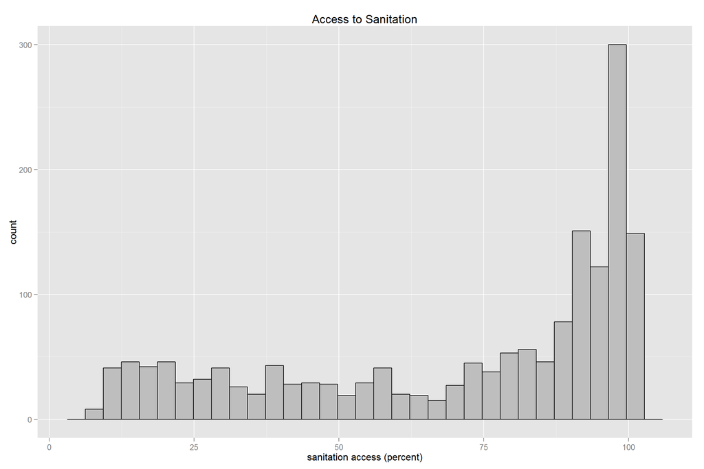

Sanitation access looks highly skewed to the left.

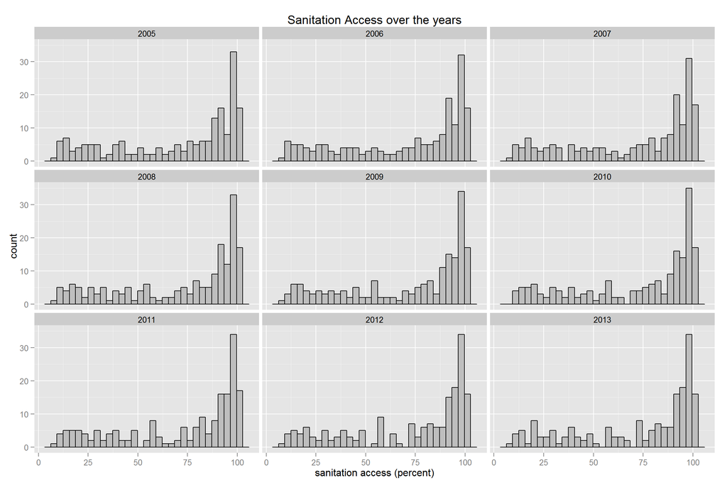

This distribution does not change with time.

Given the distribution of this indicator, we will create a factor variable with four levels:

```
    "poor" <=50%
    "regular" >50% and <=80%
    "good" >80% and <=95%
    "great" > 95%.
```

### Histogram of sanitation access

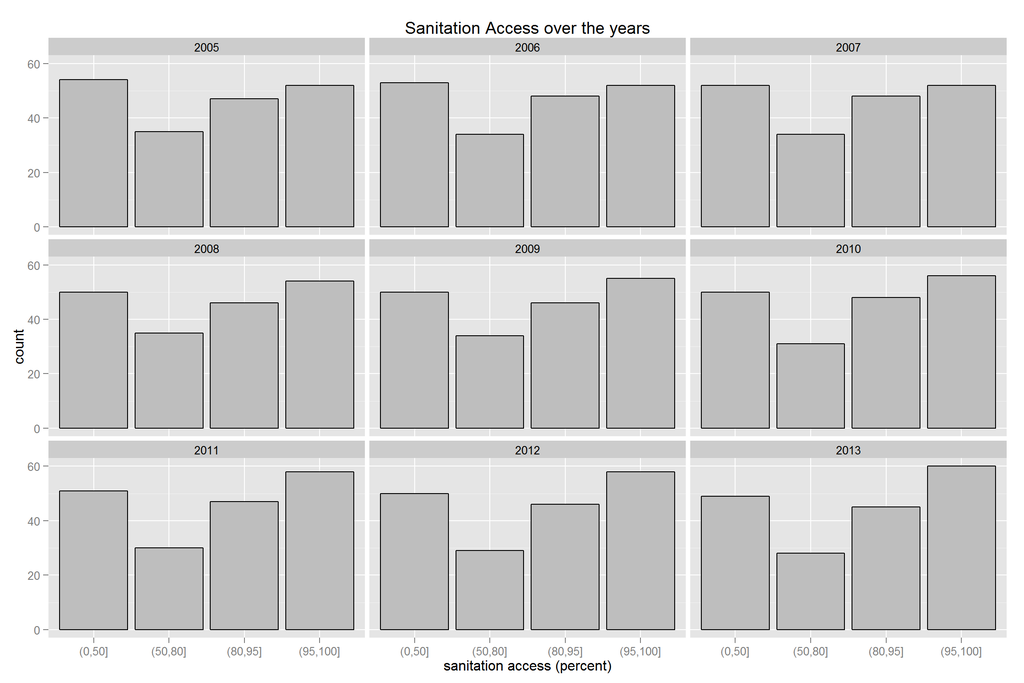

Now, let’s explore the other indicators in the dataset. As before, let’s look at how they changed over time.

### Change of GDP per capita by year

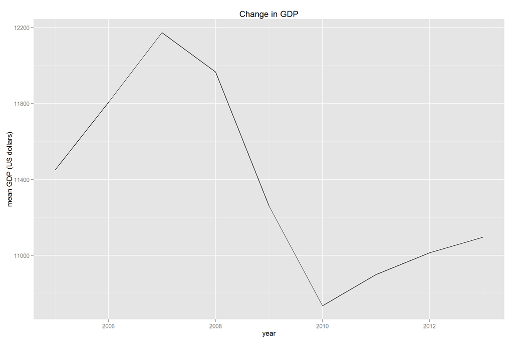

#### Let’s add a line when the financial crisis occurred

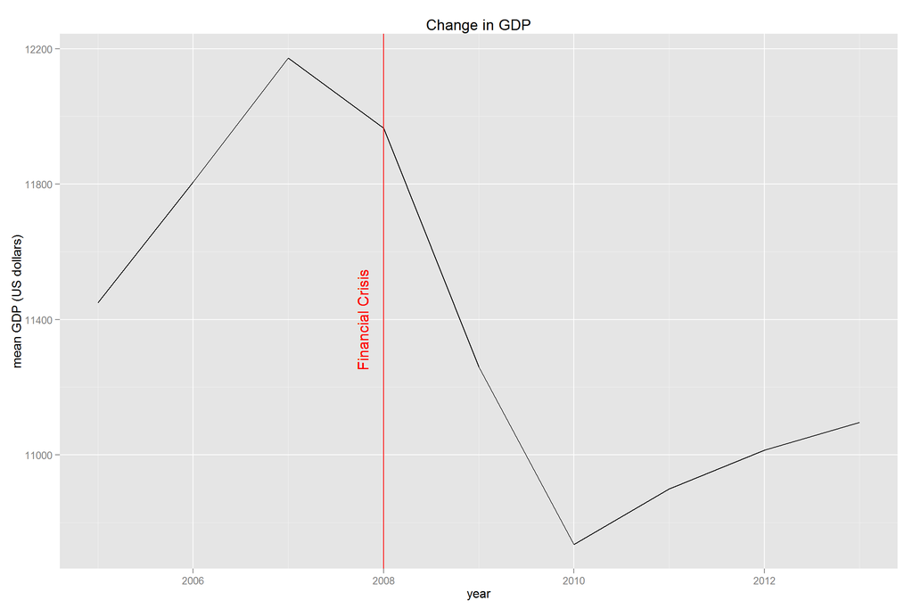

As expected, GDP decreased after the 2008 financial crisis

### Change in health expenditure per capita by year

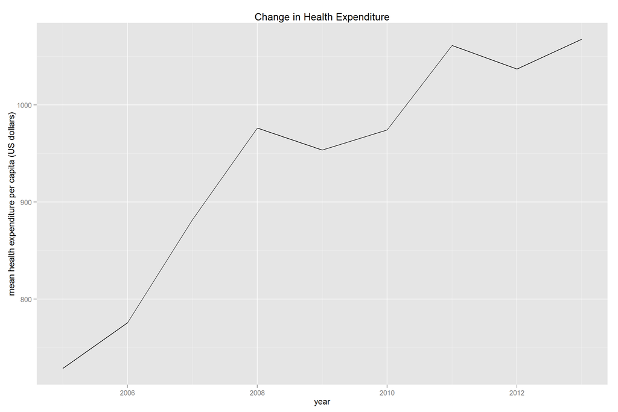

### Change in CO2 emmissions by year

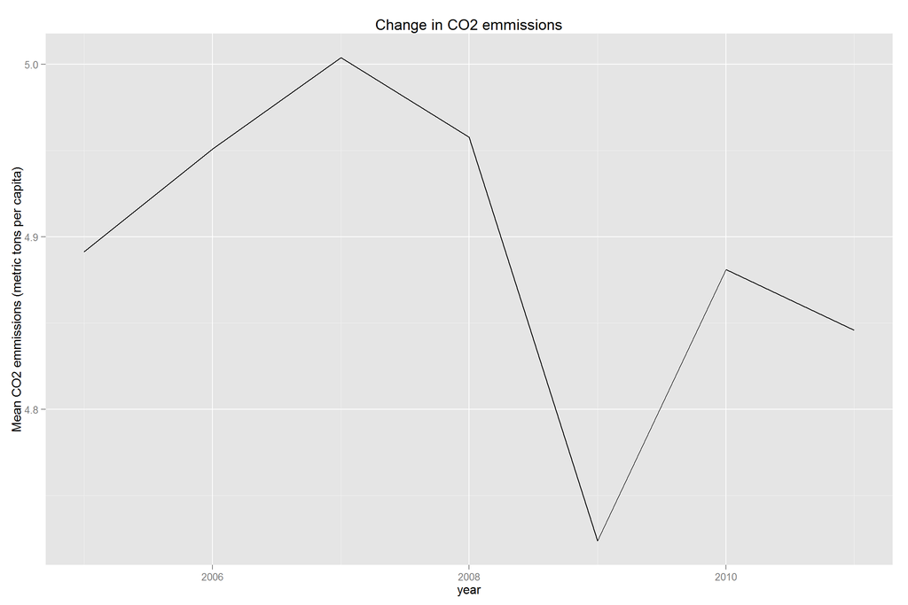

```
## $`2005`
##     Min.  1st Qu.   Median     Mean  3rd Qu.     Max.     NA's
##  0.01941  0.62730  2.24500  4.89100  7.11000 61.99000        9
##
## $`2006`
##     Min.  1st Qu.   Median     Mean  3rd Qu.     Max.     NA's
##  0.02276  0.61870  2.38600  4.95100  7.23800 57.40000        9
##
## $`2007`
##     Min.  1st Qu.   Median     Mean  3rd Qu.     Max.     NA's
##  0.02196  0.59730  2.35800  5.00400  7.05800 55.34000        9
##
## $`2008`
##     Min.  1st Qu.   Median     Mean  3rd Qu.     Max.     NA's
##  0.02162  0.58700  2.50500  4.95800  6.75100 48.60000        9
##
## $`2009`
##     Min.  1st Qu.   Median     Mean  3rd Qu.     Max.     NA's
##  0.02087  0.56400  2.42600  4.72400  6.39500 44.84000        9
##
## $`2010`
##     Min.  1st Qu.   Median     Mean  3rd Qu.     Max.     NA's
##  0.02054  0.63040  2.49500  4.88100  6.68000 42.64000        7
##
## $`2011`
##     Min.  1st Qu.   Median     Mean  3rd Qu.     Max.     NA's
##  0.02135  0.61140  2.40800  4.84600  6.69300 44.02000        8
##
## $`2012`
##    Min. 1st Qu.  Median    Mean 3rd Qu.    Max.    NA's
##      NA      NA      NA     NaN      NA      NA     196
##
## $`2013`
##    Min. 1st Qu.  Median    Mean 3rd Qu.    Max.    NA's
##      NA      NA      NA     NaN      NA      NA     196
```

CO2 emissions suffered a decrease in 2009, could be as a consequence of the financial crisis.

### Distributional differences of indicators across years.

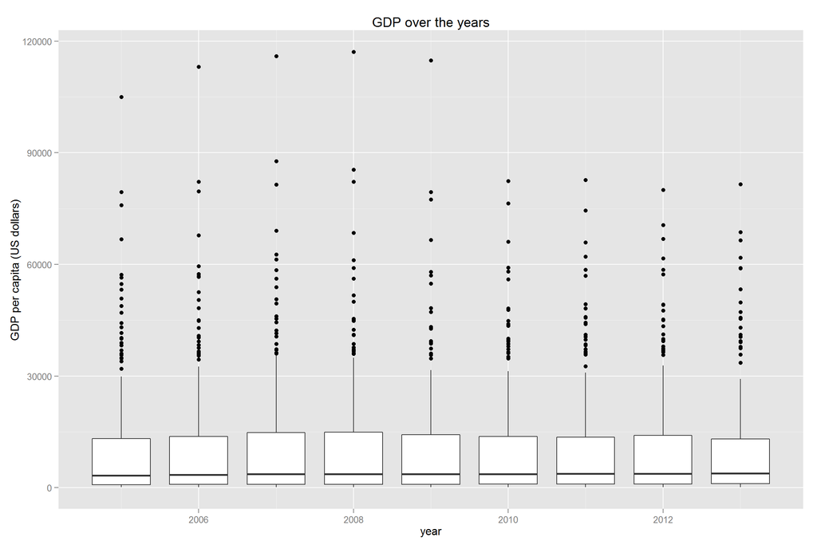

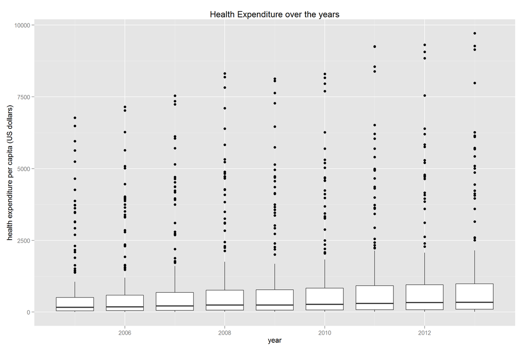

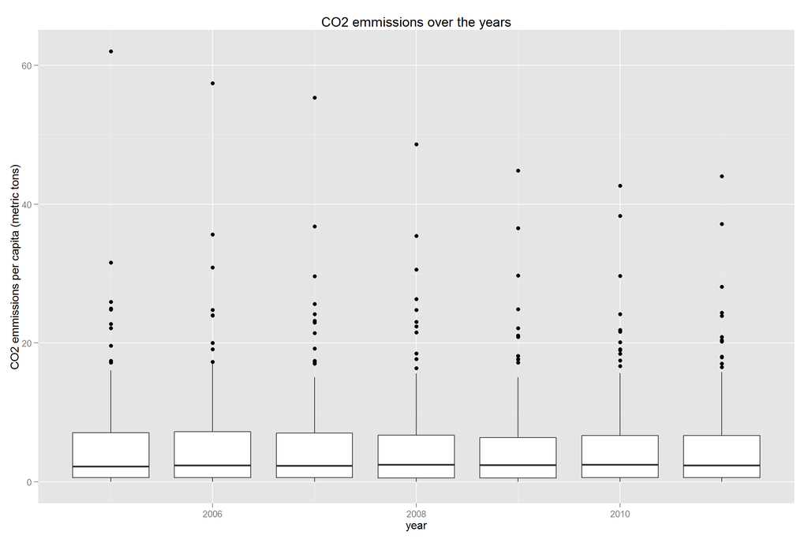

All three indicators are skewed to the right and have positive outliers, so we should be careful about this when looking at correlations.

# Univariate Analysis

### What is the structure of your dataset?

```
## [1] 1787   26
```

### What are the main features of interest in your dataset?

I am interested in exploring what indicators have an effect on `life.expect`, `life.expect.f`, and `life.expect.m`. I chose indicators from the World Bank Development Indicators database that are relevant to this question. The indicators I will focus on are: `gdp.pc`, `health.expend.pc`, `co2.em.pc`, `urban.pop.pct`, `rural.pop.pct`, `unemp.rate.tot`, `unemp.rate.f`, `unemp.rate.m`, `tropic`, `san.access.pct`

### What other features in the dataset do you think will help support your investigation into your features of interest?

I have information for different years so it is interesting to see how this indicators also change with time.

### Did you create any new variables from existing variables in the dataset?

I created the following variables:

`tropic` which equals TRUE if country is in the Tropics Region.

`rural` equals 1 if more than 50% of the population live in rural areas.

I also created aggregated datasets by year: `gdp.ocp`, `health.expend.pc`, `co2.em.pc`.

### Of the features you investigated, were there any unusual distributions? Did you perform any operations on the data to tidy, adjust, or change the form of the data?

To my knowledge, I did not find any unusual distributions. There were some missing observations that were problematic for the purpose of the study. I eliminated rows with NAs for the `life.expect` indicator and for countries where all columns where NAs.

# Bivariate Plots Section

### Investigating how life expectancy varies by country

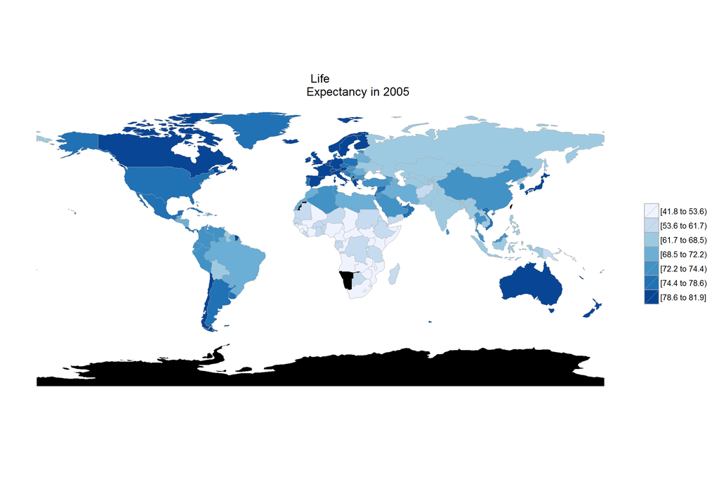

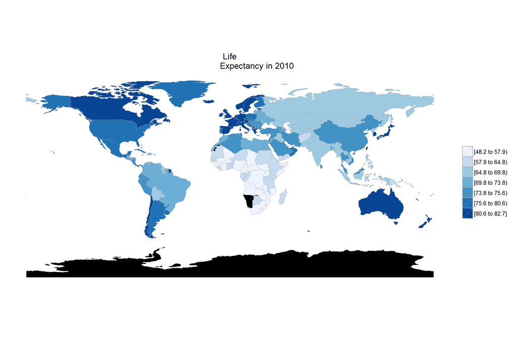

Life expectancy varies greatly by country. Countries with high average life expectancy tend to be more developed countries. From looking at this map we can think that life expectancy is strongly correlated with income level.

### Exploring bivariate relationships

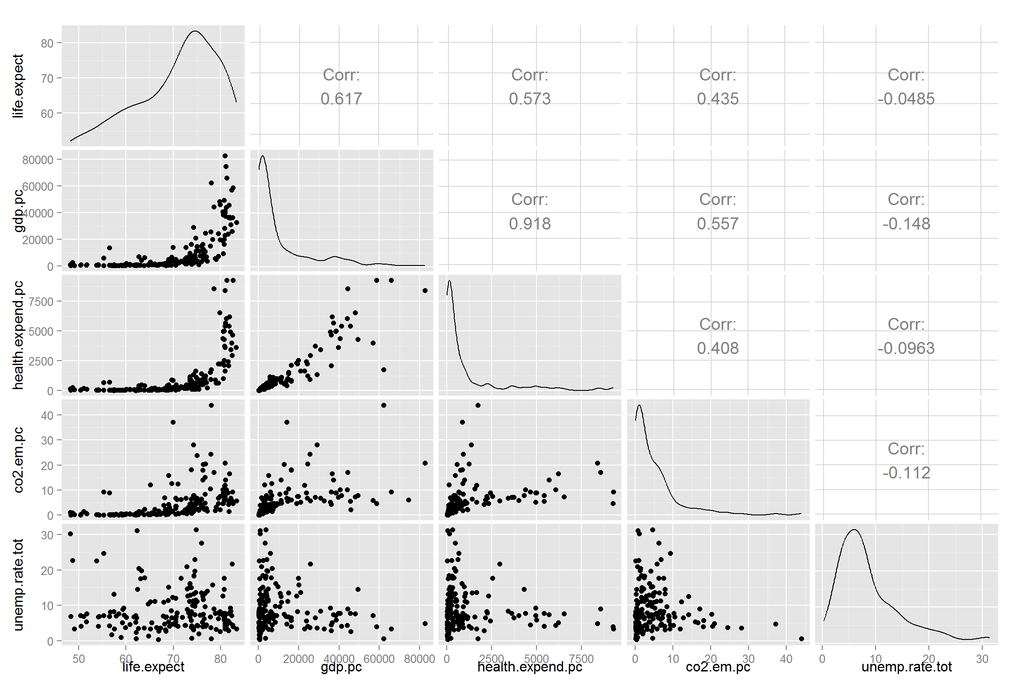

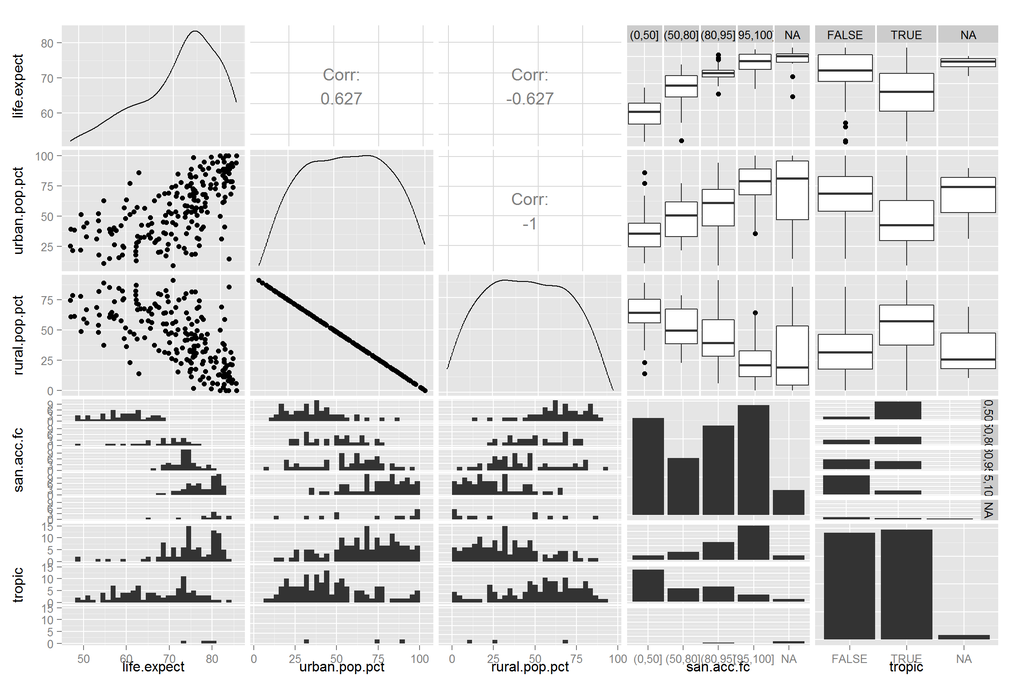

Let’s try to do some transformations to the data to account for the non-linear relationships found on some of the previous plots and add a trend line.

### Life expectancy and GDP

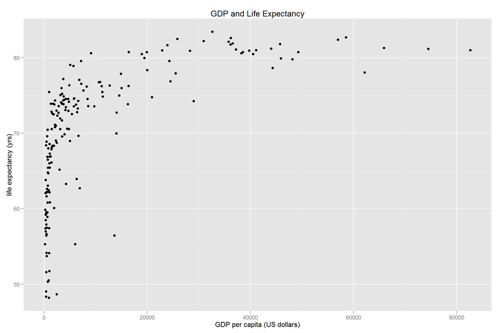

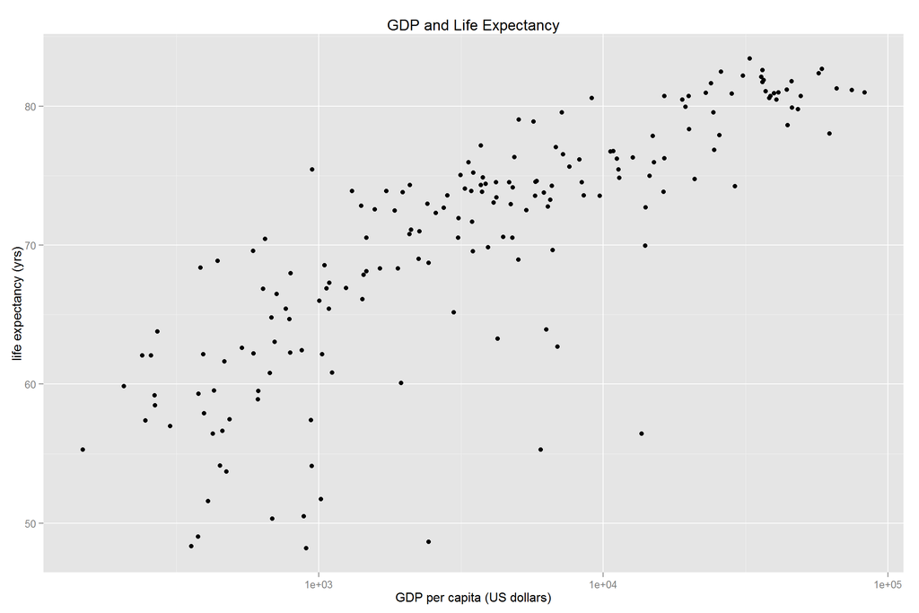

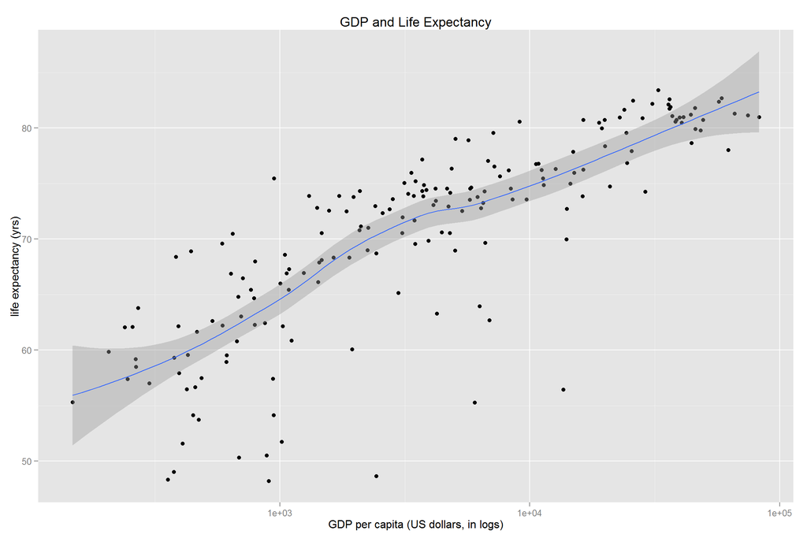

### Life expectancy and health expenditure

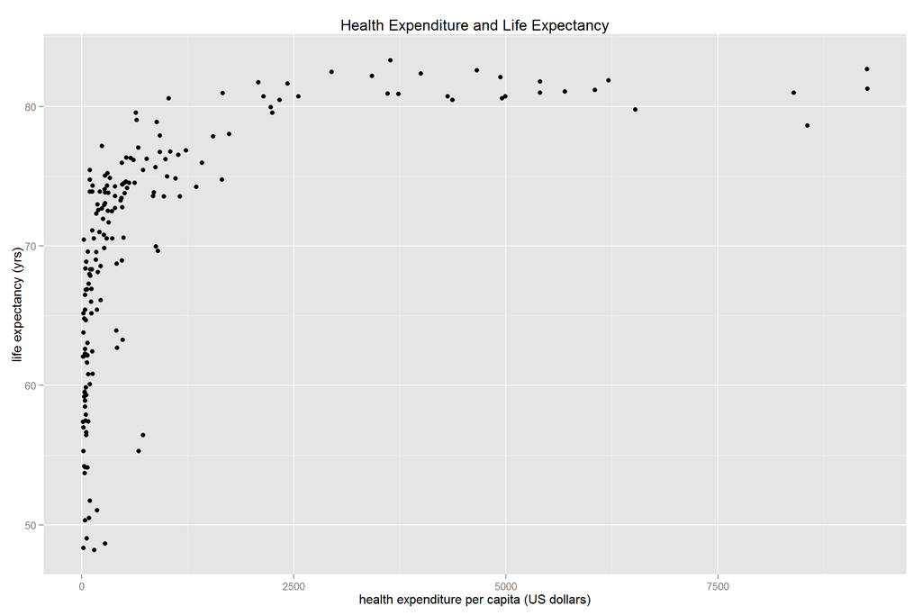

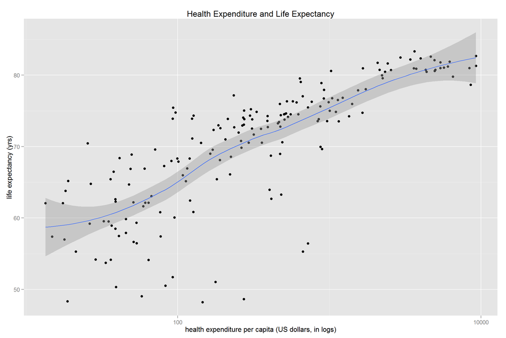

### Life expectancy and gdp: differences across gender

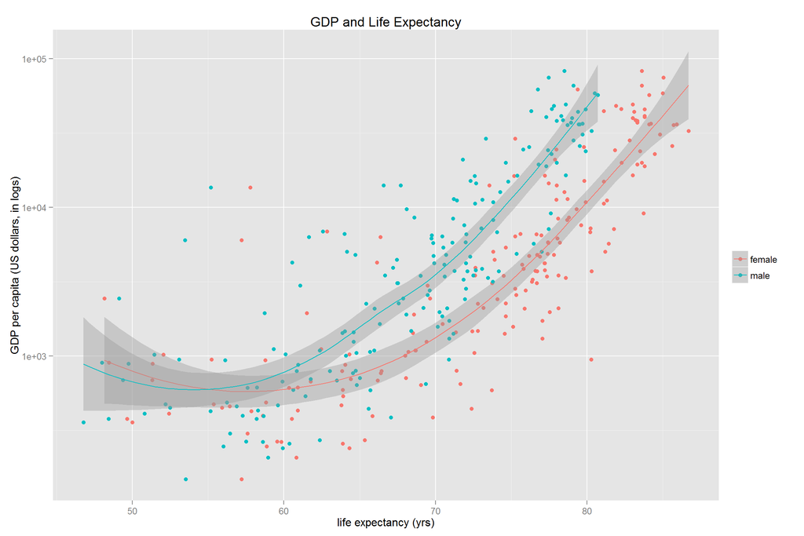

# Bivariate Analysis

### Talk about some of the relationships you observed in this part of the investigation. How did the features of interest vary with other features in the dataset?

There is a high and positive correlation between `life.expect` and `gdp.pc`, but looking at the scatter plot we see that the relationship is not linear. The same goes for `life.expect` and `health.expend.pc`.

Doing a log transformation of these indicators results in a closely linear relationship but there is some variability on the lower values of `life.expect`.

Looking at the effect of `gdp.pc` separately for men and women, we see that for countries with average life expectancy less than 60, there is no systematic difference between men and women, but for larger life expectancy values, on average men need larger GDP per capita levels to have the same life expectancy than women.

For the indicator `co2.em.pc` we have a positive correlation, not as strong as the two previously mentioned indicators, and the relationship looks more heterogeneous and appears to have some non-linearity too.

At first, I thought that `co2.em.pc` should be negatively correlated with `life.expect` because more polluted environments lead to higher incidences in respiratory diseases, etc. However, this is probably due to the fact that countries with larger emissions are mostly developed countries. Indeed, we an see the correlation between `gdp.pc` and `co2.em.pc` is strong and positive. So this correlation may be showing the effect of a country’s development level on life expectancy.

There is no apparent significant relationship between `life.expect` and `unemp.rate.tot`.

`rural` is negatively correlated with `life.expect`.

Countries with higher sanitation access have on average higher life expectancy and this is also true for countries not in the tropics region. These two indicators also show significant different distributions by category.

### Did you observe any interesting relationships between the other features?

`gdp.pc` and `health.expend.pc` are also highly positively correlated and the relationship is closely linear.

# Multivariate Plots Section

### CO2 emmissions effects: accounting for country income differences.

Here, I focused again on data for only one year to get rid of time trends. Let’s use the World Bank country income classifications to account for differences in income.

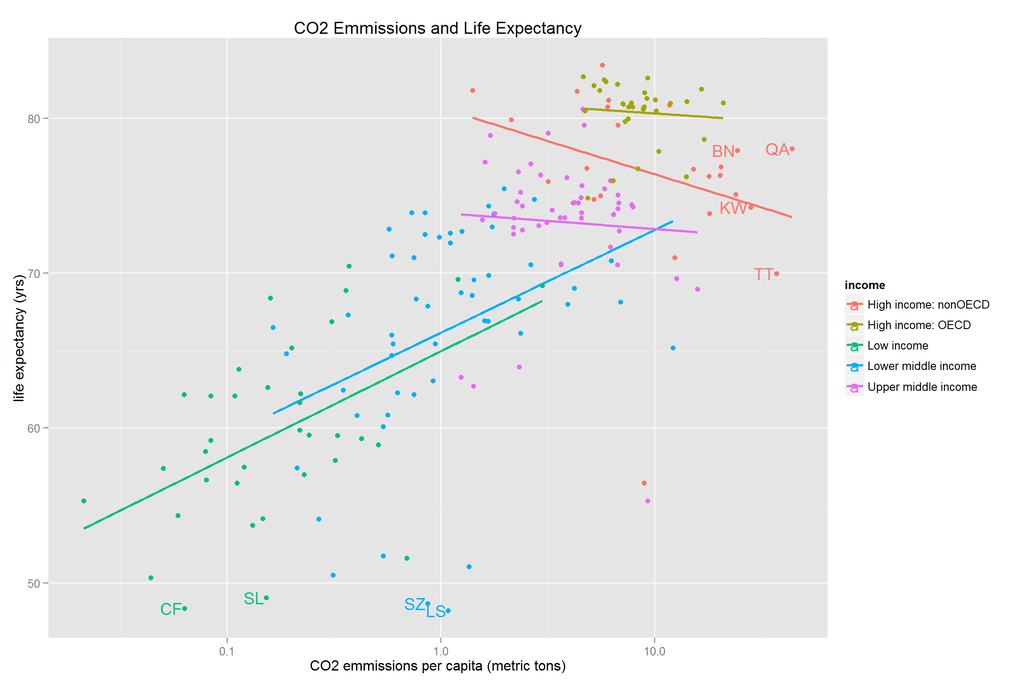

Accounting for income differences across countries, We can see that for High Income:nonOECD and upper middle income countries, `co2.em.pc` has a negative correlation with life expectancy.

#### Only non-rural countries

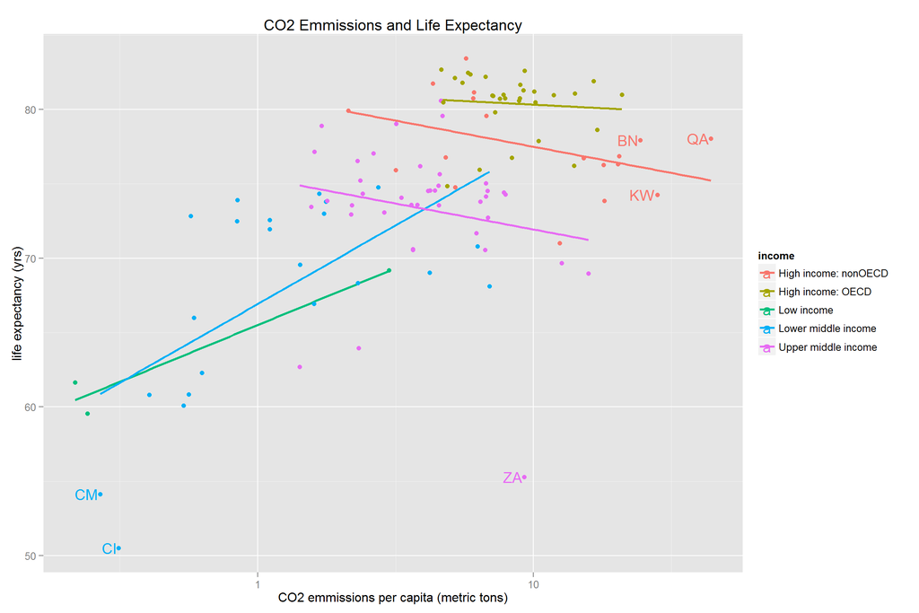

### GDP and life expectancy

Since GDP per capita and health expenditure are highly correlated, let’s focus on the effect of only one. Let’s see if the relationship between GDP and life expectancy changes for rural countries and tropical countries. Let’s also see if these differences vary by gender.

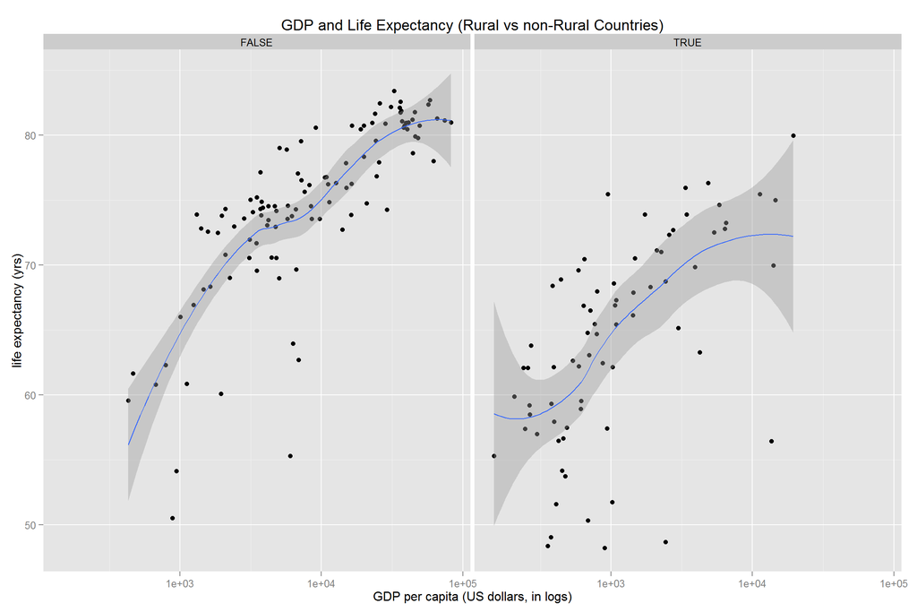

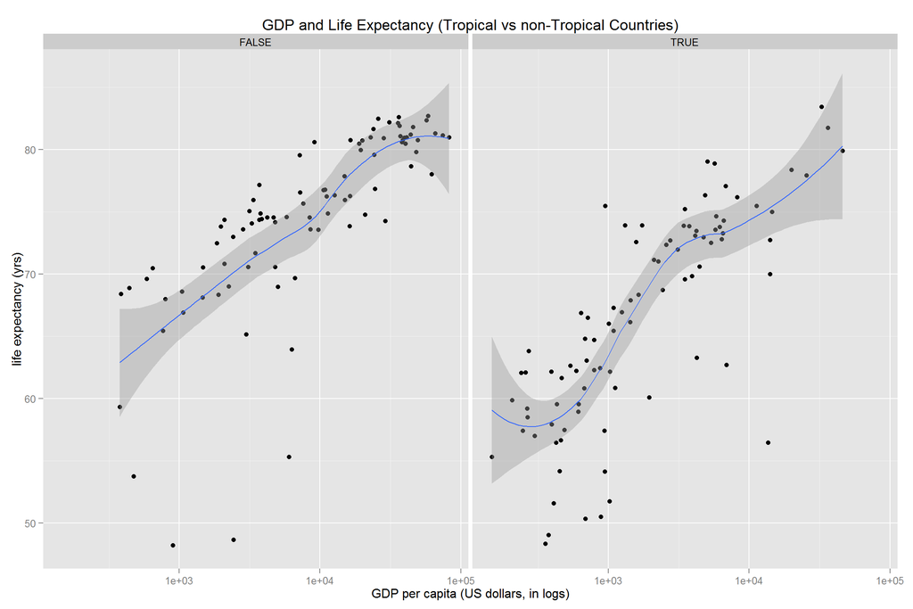

#### Differences across genders

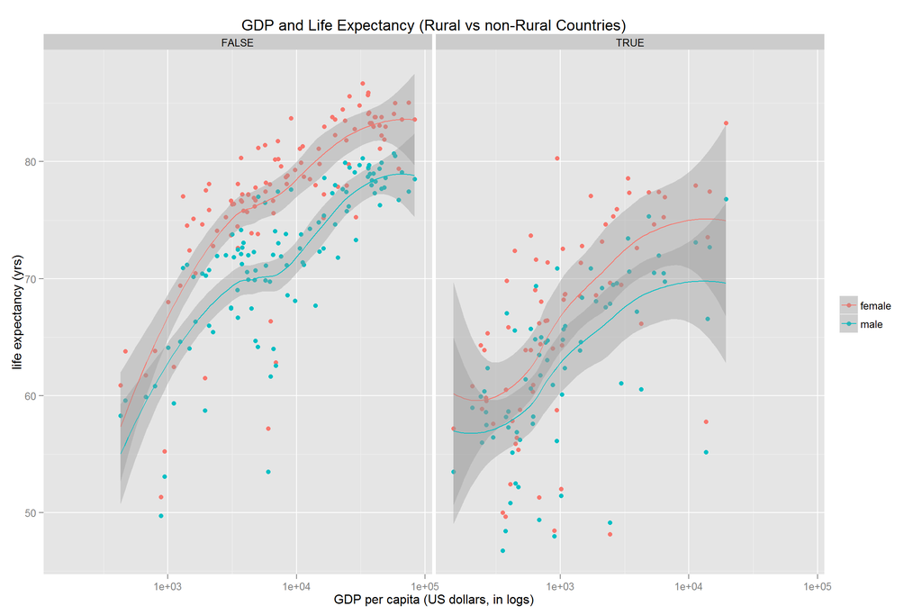

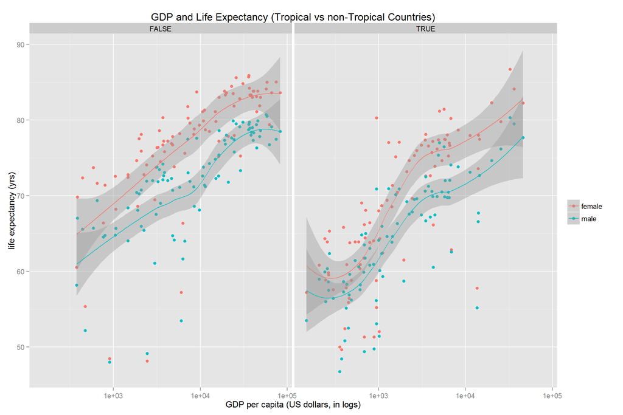